# Assignment 5

Inger Johanne Løkkevik

2022-11-19

# Analyse av repeterte målinger

### Introduksjon:

Den biologiske adaptasjon til styrkestrening hos mennesker varierer med faktorer som volum, intensitet, hvile mellom repetisjoner, anntall set, utvalg og rekkefølge på øvelser og hyppighet av styrkeøkter. (Ratamess et al.2009) Genetisk variasjon og miljøfaktorer er også medvirkende årsaker til variasjonen i adaptasjon. (Timmons,2011; Morton et al. 2018; Seaborne et al. 2018) Det er vist at individuell respons på styrketrening, herunder muskelstyrke og -masse, er korrelert med både akutte treningsfase og hvile-fase endringer i muskelcellene (Terzis et al.2008; Raue et al. 2012; Thalacker-Mercer et al 2013; Stec et al. 2016). Hos høy-respondere ser man en høyere rRNA-stigning enn hos lav-responderne.(Stec.et al 2016; Mobley et al 2018) Muskelfibersammensetning kan også ha betydning for muskelrespons på styrketrening.  
Med treningsvolum menes den totale belastningen man utsetter muskulaturen for gjennom vekt/load, antall repetisjoner og sett. Muskelmassen er den totale masse skjelettmuskulaturhos testpersonene. Styrke defineres som evnen en muskel eller muskelgruppe har til å utvikle kraft. 1RM er den vekt man kan løfte maximalt 1 repetisjon.

Gjennom studiet ønsker jeg å se om det er en forskjell i økning av muskelstyrke ved å gjennomføre styrketrening i ett sett hhv flere sett

### Metode:

Førtien ikke-røykende kvinner (22) og menn (19) mellom 18 og 40 år ble inkludert i studien. Eksklusjonskriterier var allergi mot lokalanestesi, treningshistorikk med mer enn en ukentlig styrkeøkt i uka de siste 12 mndr før intervensjonen, fast medikasjon som ville kunne ha innvirkning på adaptasjon til trening og muskelsvekkelse pga tidligere skader. Syv deltakere, 4 kvinner og 3 menn, ble ekskludert under studiet pga manglede gjennomførte økter (85%). Årsakene til dette var smerter eller ubehag i underekstremitetene under trening (n=5), skade ikke relatert til studiet (n=1) og manglende complience (n=1). Alle deltakerne rapporterte at de hadde erfaring fra trening og 20 av deltakere drev med fysisk aktivitet før intervensjonsstart, men ikke ukentlig styrketrening.

Før alle treningsøkter, ble det gjennomført et standarisert oppvarmingsprogram, etterfulgt av kroppsvektøvelser (push-ups, situps, rygghev og squats) og ett sett med 10 reps 50% av 1RM av benøvelser. Disse ble utført i samme rekkefølge; unilat. legpress, legcurl og kneekstensjon og i enten 1 sett (single-set) eller 3 sett (multiple-set). Single-set ble utført mellom andre og tredje sett av multiple-set protokollen. Etter beinøvelsene, gjennomførte deltakerne to sett av benkpress, nedtrekk, skulderpress eller sittende roing. Restitusjonstid mellom sett var mellom 90 og 180 s. Treningsintensiteten ble økt gradvisgjennom intervensjonsperioden, fra 10RM de første to ukene, via 8RM i 3 uker til 7RM i 7 uker. 91% av øktene var supervisert. Mellom økter med max anstrengelse skulle det gå minimum 48t og mellom økter med submaximal anstrengelse 24t. Etter hver økt fikk alle deltakere en standarisert drikke med 0.15g protein /kg, 11.2 g karbohydrat/kg og 0.5 g fett/kg.

```r
#| echo: false
#| warning: false
#| message: false

library(exscidata)
library(tidyverse)
library(modelr)
library(gt)
library(gtExtras)
library(knitr)
library(kableExtra)
library(flextable)
library(lmerTest)
library(lme4)


data("dxadata"); data("strengthvolume")
```

```r
#| echo: false
#| warning: false
#| message: false

?strengthvolume
?dxadata
```

#### Beregner prosentvis endring i fettfri masse mellom gruppene

```r
#| echo: false
#| warning: false
#| message: false


dat<- dxadata %>%
  select(participant:include, sex,lean.left_leg, lean.right_leg) %>%
  pivot_longer(names_to = "leg",
               values_to = "lean.legs",
               cols = lean.left_leg:lean.right_leg) %>%
  mutate(leg = if_else(leg== "lean.left_leg", "L", "R"),
         sets = if_else(multiple == leg, "multiple", "single")) %>%
  filter(include == "incl") %>%
  select(participant, time,sex, include, sets, leg, lean.legs) %>%

  pivot_wider(names_from = time,
              values_from = lean.legs) %>%
  mutate(lbmleg.change =post-pre,
         pre.mc =pre - mean(pre)) %>%
  mutate(pros.change =((post-pre) /pre) *100) %>%
  filter(!is.na(lbmleg.change)) %>%

  print()
```

```
## # A tibble: 68 × 10
##    participant sex    include sets     leg     pre  post lbmle…¹  pre.mc pros.…²
##    <chr>       <chr>  <chr>   <chr>    <chr> <dbl> <dbl>   <dbl>   <dbl>   <dbl>
##  1 FP28        female incl    multiple L      7059  7273     214 -1537.   3.03
##  2 FP28        female incl    single   R      7104  7227     123 -1492.   1.73
##  3 FP40        female incl    single   L      7190  7192       2 -1406.   0.0278
##  4 FP40        female incl    multiple R      7506  7437     -69 -1090.  -0.919
##  5 FP21        male   incl    single   L     10281 10470     189  1685.   1.84
##  6 FP21        male   incl    multiple R     10200 10819     619  1604.   6.07
##  7 FP34        female incl    single   L      6014  6326     312 -2582.   5.19
##  8 FP34        female incl    multiple R      6009  6405     396 -2587.   6.59
##  9 FP23        male   incl    single   L      8242  8687     445  -354.   5.40
## 10 FP23        male   incl    multiple R      8685  8480    -205    88.7 -2.36
## # … with 58 more rows, and abbreviated variable names ¹lbmleg.change,
## #   ²pros.change
```

#### Beregner gjennomsnittlig standardavvik (Mean SD)

```
## # A tibble: 2 × 2
##   sets     meansd
##   <chr>    <chr>
## 1 multiple 3.37(4.59)
## 2 single   2.05(3.62)
```

```
## [1] "multiple" "single"
```

```
## [1] "3.37(4.59)" "2.05(3.62)"
```

```r
#| echo: false
#| warning: false
#| message: false


m0 <- lme4::lmer(post ~ pre + sex + sets + (1|participant), data = dat)
summary(m0)
```

```
## Linear mixed model fit by REML ['lmerMod']
## Formula: post ~ pre + sex + sets + (1 | participant)
##    Data: dat
##
## REML criterion at convergence: 951.6
##
## Scaled residuals:
##      Min       1Q   Median       3Q      Max
## -2.16339 -0.55999  0.03483  0.45253  1.49108
##
## Random effects:
##  Groups      Name        Variance Std.Dev.
##  participant (Intercept) 92349    303.9
##  Residual                51744    227.5
## Number of obs: 68, groups:  participant, 34
##
## Fixed effects:
##               Estimate Std. Error t value
## (Intercept)  604.58946  368.30907   1.642
## pre            0.94743    0.05072  18.679
## sexmale      290.59159  203.81270   1.426
## setssingle  -123.55792   55.17543  -2.239
##
## Correlation of Fixed Effects:
##            (Intr) pre    sexmal
## pre        -0.973
## sexmale     0.705 -0.815
## setssingle -0.088  0.013 -0.011
## fit warnings:
## Some predictor variables are on very different scales: consider rescaling
```

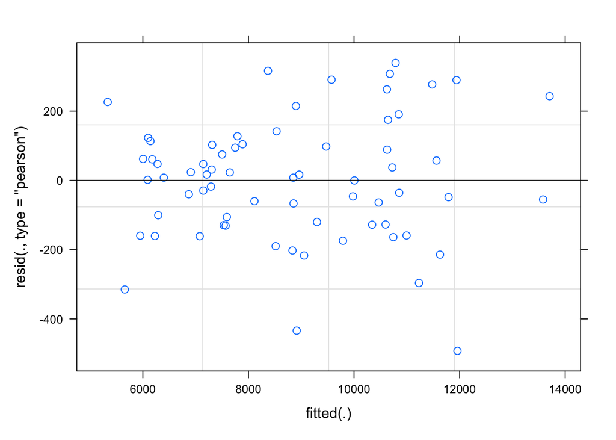

```r
plot(m0)
```

```r
confint(m0)
```

```
## Computing profile confidence intervals ...
```

```
##                   2.5 %      97.5 %
## .sig01       201.703720  396.941748
## .sigma       179.355748  290.662544
## (Intercept) -107.769056 1337.570567
## pre            0.846308    1.045576
## sexmale     -102.219992  693.375809
## setssingle  -233.172861  -13.806501
```

### Posentvis økning i styrke mellom gruppne

```r
#| echo: false
#| warning: false
#| message: false


strength <- strengthvolume %>%
  group_by(exercise) %>%
  mutate(scaled.load = load / max(load, na.rm = TRUE)) %>%
  group_by(participant, time, sex, sets) %>%
  summarise(combined.load = mean(scaled.load, na.rm = TRUE)) %>%
  ungroup() %>%
  pivot_wider(names_from = time,
              values_from = combined.load) %>%
  mutate(pros.change= ((post - pre) / pre) * 100) %>%
  print()
```

```
## # A tibble: 78 × 10
##    participant sex    sets      post   pre session1 week2 week5 week9 pros.cha…¹
##    <chr>       <chr>  <chr>    <dbl> <dbl>    <dbl> <dbl> <dbl> <dbl>      <dbl>
##  1 FP1         male   multiple 0.696 0.560    0.541 0.572 0.626 0.715       24.2
##  2 FP1         male   single   0.687 0.603    0.628 0.674 0.693 0.722       14.0
##  3 FP11        male   multiple 0.776 0.604    0.594 0.711 0.772 0.737       28.3
##  4 FP11        male   single   0.708 0.568    0.570 0.637 0.693 0.644       24.6
##  5 FP12        female multiple 0.757 0.601    0.627 0.652 0.637 0.715       25.9
##  6 FP12        female single   0.729 0.559    0.600 0.634 0.597 0.680       30.5
##  7 FP13        male   multiple 0.732 0.512    0.528 0.600 0.660 0.698       42.9
##  8 FP13        male   single   0.757 0.531    0.541 0.597 0.673 0.711       42.6
##  9 FP14        female multiple 0.518 0.364    0.324 0.440 0.448 0.511       42.5
## 10 FP14        female single   0.490 0.395    0.382 0.431 0.445 0.470       24.0
## # … with 68 more rows, and abbreviated variable name ¹pros.change
```

```r
strength %>%
  filter(!is.na(post)) %>%
  group_by(sets) %>%
  summarise(m = mean(pros.change),
            sd = sd(pros.change)) %>%
  mutate(meansd= paste0(signif(m, 3), "(", signif(sd, 3), ")")) %>%
  select(sets, meansd) %>%
  print()
```

```
## # A tibble: 2 × 2
##   sets     meansd
##   <chr>    <chr>
## 1 multiple 31(14.2)
## 2 single   24.5(12.9)
```

#### Regresjonsmodell

```
## Linear mixed model fit by REML ['lmerMod']
## Formula: post ~ pre + sex + sets + (1 | participant)
##    Data: strength
##
## REML criterion at convergence: -221.2
##
## Scaled residuals:
##     Min      1Q  Median      3Q     Max
## -1.8781 -0.4709 -0.1018  0.5958  1.4745
##
## Random effects:
##  Groups      Name        Variance  Std.Dev.
##  participant (Intercept) 0.0024439 0.04944
##  Residual                0.0007301 0.02702
## Number of obs: 72, groups:  participant, 36
##
## Fixed effects:
##              Estimate Std. Error t value
## (Intercept)  0.183280   0.038364   4.777
## pre          0.848904   0.091541   9.274
## sexmale      0.067136   0.024689   2.719
## setssingle  -0.029263   0.006378  -4.588
##
## Correlation of Fixed Effects:
##            (Intr) pre    sexmal
## pre        -0.945
## sexmale     0.503 -0.697
## setssingle -0.133  0.053 -0.037
```

```
##                   2.5 %      97.5 %
## .sig01       0.03594193  0.06298848
## .sigma       0.02136358  0.03426735
## (Intercept)  0.10782107  0.26013926
## pre          0.66502431  1.02963482
## sexmale      0.01927314  0.11613940
## setssingle  -0.04186768 -0.01657808
```

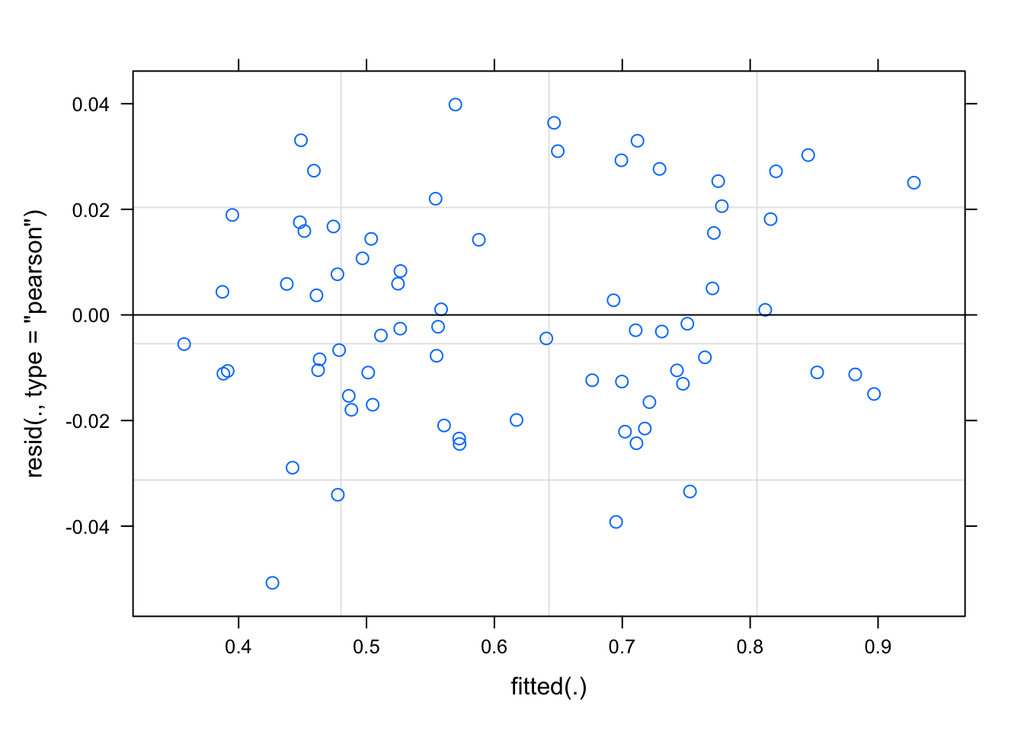

## Statistiske analyser

#### Tabell Endring fettfri masse fordelt på intervensjonsgrupper.

```r
#| echo: false
#| warning: false
#| message: false



lbmleg <- dat %>%
  filter(!is.na(post)) %>%
  group_by(sets) %>%
  summarise(m = mean(pros.change),
            sd = sd(pros.change)) %>%
  mutate(meansd= paste0(signif(m, 3), "(", signif(sd, 3), ")")) %>%
  select(sets, meansd)


tabell_lbmleg <- lbmleg %>%
mutate(sets = factor(sets, levels = c("multiple", "single"),
                        labels = c("Flersett", "Enkeltsett"))) %>%
  select(sets, meansd) %>%
  arrange(sets) %>%
   flextable()  %>%
  set_header_labels(sets = " ",
                    meansd = "Tabell 2 - Økning fettfri masse i prosent")%>%
    add_footer_row(values = "Gjennomsnittlig prosentvis endring(SD), fra pre til post", colwidths = 2) %>%

    autofit()
tabell_lbmleg
```

|  | Tabell 2 - Økning fettfri masse i prosent |
| --- | --- |
| Flersett | 3.37(4.59) |
| Enkeltsett | 2.05(3.62) |

Gjennomsnittlig prosentvis endring(SD), fra pre til post

```r
#| echo: false
#| warning: false
#| message: false



strength.change <- strength %>%
  filter(!is.na(post)) %>%
  group_by(sets) %>%
  summarise(m = mean(pros.change),
            sd = sd(pros.change)) %>%
  mutate(meansd= paste0(signif(m, 3), "(", signif(sd, 3), ")")) %>%
  select(sets, meansd)


tabell_strengthchange <- strength.change %>%
mutate(sets = factor(sets, levels = c("multiple", "single"),
                        labels = c("Flersett", "Enkeltsett"))) %>%
  select(sets, meansd) %>%
  arrange(sets) %>%
   flextable()  %>%
  set_header_labels(sets = " ",
                    meansd = "Tabell 3 - Økning beinstyrke i prosent")%>%
    add_footer_row(values = "Gjennomsnittlig prosentvis endring(SD), fra pre til post", colwidths = 2) %>%

    autofit()
tabell_strengthchange
```

|  | Tabell 3 - Økning beinstyrke i prosent |
| --- | --- |
| Flersett | 31(14.2) |
| Enkeltsett | 24.5(12.9) |

Gjennomsnittlig prosentvis endring(SD), fra pre til post

## Resultater

### Muskelmasse

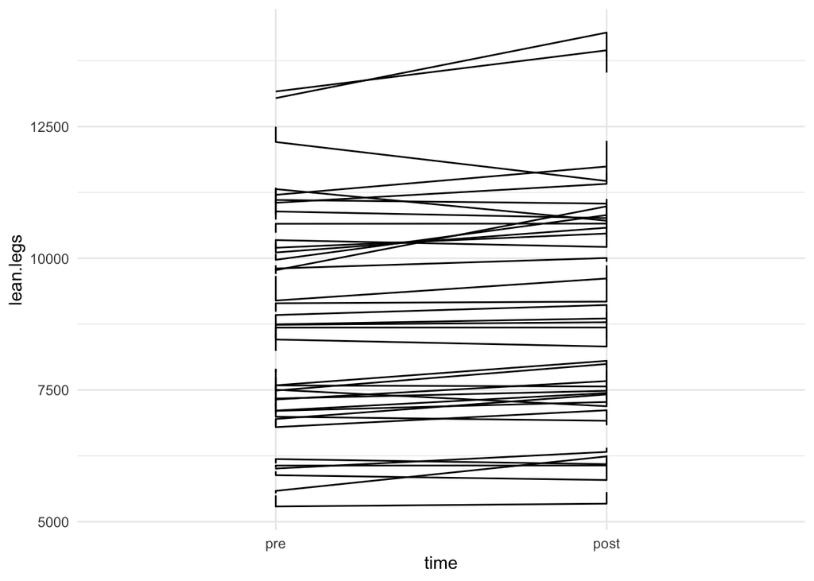

```r
#| echo: false
#| warning: false
#| message: false



plotdata <- dxadata %>%
  select(participant:include, sex, lean.left_leg, lean.right_leg) %>%
  pivot_longer(names_to = "leg",
               values_to = "lean.legs",
               cols = lean.left_leg:lean.right_leg) %>%
  mutate(leg = if_else(leg == "lean.left_leg", "L", "R"),
         sets = if_else(multiple == leg, "multiple", "single")) %>%
  select(participant, time, sets, sex, leg, lean.legs) %>%
  group_by(participant) %>%
  mutate(n = n(), group = factor(sets, levels = c("single", "multiple")), time = factor(time, levels = c("pre", "post")))
plotdata %>%
 ggplot(aes(time, lean.legs, group = participant)) + geom_line() + theme_minimal()
```

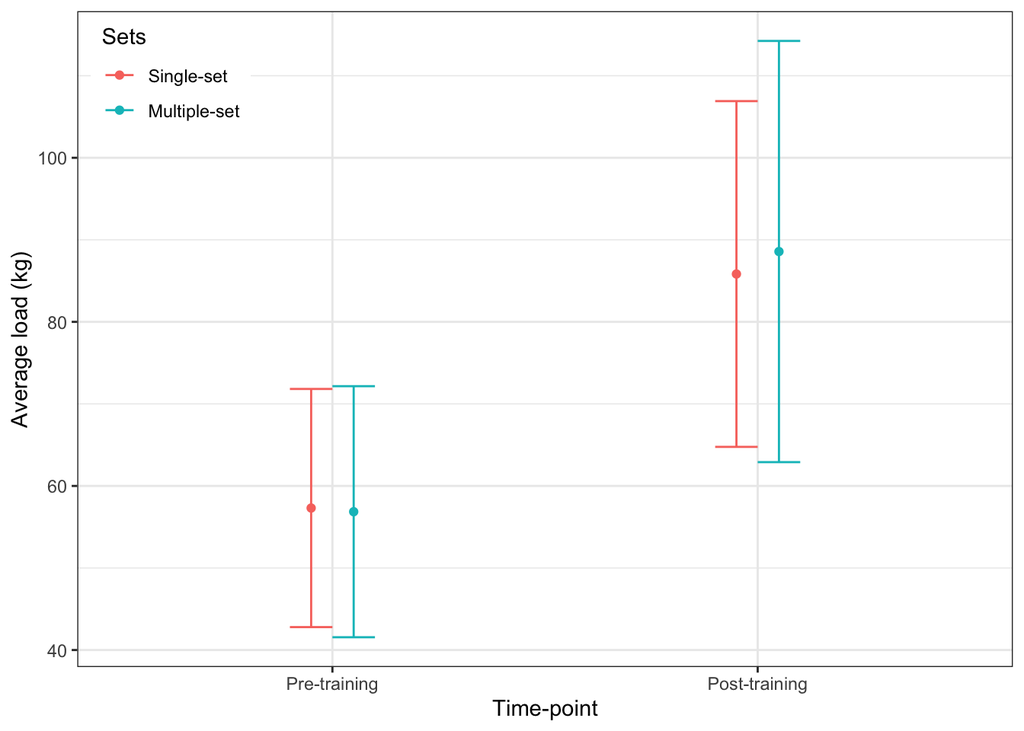

```r
#| echo: false
#| warning: false
#| message: false


strengthvolume %>%
  filter(exercise == "legext", time %in% c("pre", "post")) %>%
  group_by(sets, time) %>%
  summarise(m = mean(load, na.rm = TRUE),
            s = sd(load, na.rm = TRUE)) %>%
  mutate(time = factor(time, levels = c("pre", "post"), labels = c("Pre-training", "Post-training")),
         sets = factor(sets, levels = c("single", "multiple"), labels = c("Single-set", "Multiple-set"))) %>%
  ggplot(aes(time, m, color = sets)) +

  geom_errorbar(aes(ymin = m - s, ymax = m + s),
                position = position_dodge(width = 0.2),
                width = 0.2) +
  geom_point(position = position_dodge(width = 0.2)) +

  labs(x = "Time-point",
       y = "Average load (kg)",
       color = "Sets") +

  theme_bw() +

  theme(legend.position = c(0.1, 0.9))
```